# Risk Factor Analysis

## Outcome Variable

**Outcome Variable:** haz

## Predictor Variables

**Intervention Variable:** predfeed3

**Adjustment Set:**

- arm
- sex
- month
- brthmon
- W_mage
- meducyrs
- feducyrs
- hhwealth_quart
- hfoodsec
- W_mhtcm
- W_mwtkg
- W_mbmi
- vagbrth
- W_gagebrth
- W_birthwt
- W_birthlen
- W_nrooms
- W_nchldlt5
- W_parity
- impfloor
- impsan
- safeh20
- delta_W_mage
- delta_meducyrs
- delta_feducyrs
- delta_hhwealth_quart
- delta_hfoodsec
- delta_W_mhtcm
- delta_W_mwtkg
- delta_W_mbmi
- delta_vagbrth
- delta_W_gagebrth
- delta_W_birthwt
- delta_W_birthlen
- delta_W_nrooms
- delta_W_nchldlt5
- delta_W_parity
- delta_impfloor
- delta_impsan
- delta_safeh20

## Stratifying Variables

The analysis was stratified on these variable(s):

- agecat
- studyid
- country

## Data Summary

| agecat | studyid | country | predfeed3 | n_cell | n | outcome_variable |
| --- | --- | --- | --- | --- | --- | --- |
| Birth | EE | PAKISTAN | 1 | 35 | 35 | haz |
| Birth | EE | PAKISTAN | 0 | 0 | 35 | haz |
| Birth | GMS-Nepal | NEPAL | 1 | 380 | 458 | haz |
| Birth | GMS-Nepal | NEPAL | 0 | 78 | 458 | haz |
| Birth | JiVitA-3 | BANGLADESH | 1 | 12017 | 13276 | haz |
| Birth | JiVitA-3 | BANGLADESH | 0 | 1259 | 13276 | haz |
| Birth | JiVitA-4 | BANGLADESH | 1 | 105 | 116 | haz |
| Birth | JiVitA-4 | BANGLADESH | 0 | 11 | 116 | haz |
| Birth | MAL-ED | BANGLADESH | 1 | 176 | 215 | haz |
| Birth | MAL-ED | BANGLADESH | 0 | 39 | 215 | haz |
| Birth | MAL-ED | BRAZIL | 1 | 24 | 57 | haz |
| Birth | MAL-ED | BRAZIL | 0 | 33 | 57 | haz |
| Birth | MAL-ED | INDIA | 1 | 29 | 41 | haz |
| Birth | MAL-ED | INDIA | 0 | 12 | 41 | haz |
| Birth | MAL-ED | NEPAL | 1 | 14 | 26 | haz |
| Birth | MAL-ED | NEPAL | 0 | 12 | 26 | haz |
| Birth | MAL-ED | PERU | 1 | 150 | 223 | haz |
| Birth | MAL-ED | PERU | 0 | 73 | 223 | haz |
| Birth | MAL-ED | SOUTH AFRICA | 1 | 33 | 100 | haz |
| Birth | MAL-ED | SOUTH AFRICA | 0 | 67 | 100 | haz |
| Birth | MAL-ED | TANZANIA, UNITED REPUBLIC OF | 1 | 26 | 102 | haz |
| Birth | MAL-ED | TANZANIA, UNITED REPUBLIC OF | 0 | 76 | 102 | haz |
| 6 months | EE | PAKISTAN | 1 | 39 | 39 | haz |
| 6 months | EE | PAKISTAN | 0 | 0 | 39 | haz |
| 6 months | GMS-Nepal | NEPAL | 1 | 367 | 441 | haz |
| 6 months | GMS-Nepal | NEPAL | 0 | 74 | 441 | haz |
| 6 months | JiVitA-3 | BANGLADESH | 1 | 8516 | 9328 | haz |
| 6 months | JiVitA-3 | BANGLADESH | 0 | 812 | 9328 | haz |
| 6 months | JiVitA-4 | BANGLADESH | 1 | 76 | 88 | haz |
| 6 months | JiVitA-4 | BANGLADESH | 0 | 12 | 88 | haz |
| 6 months | MAL-ED | BANGLADESH | 1 | 191 | 233 | haz |
| 6 months | MAL-ED | BANGLADESH | 0 | 42 | 233 | haz |
| 6 months | MAL-ED | BRAZIL | 1 | 93 | 187 | haz |
| 6 months | MAL-ED | BRAZIL | 0 | 94 | 187 | haz |
| 6 months | MAL-ED | INDIA | 1 | 147 | 210 | haz |
| 6 months | MAL-ED | INDIA | 0 | 63 | 210 | haz |
| 6 months | MAL-ED | NEPAL | 1 | 113 | 227 | haz |
| 6 months | MAL-ED | NEPAL | 0 | 114 | 227 | haz |
| 6 months | MAL-ED | PERU | 1 | 176 | 270 | haz |
| 6 months | MAL-ED | PERU | 0 | 94 | 270 | haz |
| 6 months | MAL-ED | SOUTH AFRICA | 1 | 63 | 244 | haz |
| 6 months | MAL-ED | SOUTH AFRICA | 0 | 181 | 244 | haz |
| 6 months | MAL-ED | TANZANIA, UNITED REPUBLIC OF | 1 | 64 | 212 | haz |
| 6 months | MAL-ED | TANZANIA, UNITED REPUBLIC OF | 0 | 148 | 212 | haz |
| 24 months | EE | PAKISTAN | 1 | 20 | 20 | haz |
| 24 months | EE | PAKISTAN | 0 | 0 | 20 | haz |
| 24 months | GMS-Nepal | NEPAL | 1 | 322 | 384 | haz |
| 24 months | GMS-Nepal | NEPAL | 0 | 62 | 384 | haz |
| 24 months | JiVitA-3 | BANGLADESH | 1 | 4434 | 4852 | haz |
| 24 months | JiVitA-3 | BANGLADESH | 0 | 418 | 4852 | haz |
| 24 months | JiVitA-4 | BANGLADESH | 1 | 136 | 151 | haz |
| 24 months | JiVitA-4 | BANGLADESH | 0 | 15 | 151 | haz |
| 24 months | MAL-ED | BANGLADESH | 1 | 168 | 205 | haz |
| 24 months | MAL-ED | BANGLADESH | 0 | 37 | 205 | haz |
| 24 months | MAL-ED | BRAZIL | 1 | 79 | 152 | haz |
| 24 months | MAL-ED | BRAZIL | 0 | 73 | 152 | haz |
| 24 months | MAL-ED | INDIA | 1 | 139 | 202 | haz |
| 24 months | MAL-ED | INDIA | 0 | 63 | 202 | haz |
| 24 months | MAL-ED | NEPAL | 1 | 110 | 220 | haz |
| 24 months | MAL-ED | NEPAL | 0 | 110 | 220 | haz |
| 24 months | MAL-ED | PERU | 1 | 131 | 198 | haz |
| 24 months | MAL-ED | PERU | 0 | 67 | 198 | haz |
| 24 months | MAL-ED | SOUTH AFRICA | 1 | 60 | 228 | haz |
| 24 months | MAL-ED | SOUTH AFRICA | 0 | 168 | 228 | haz |
| 24 months | MAL-ED | TANZANIA, UNITED REPUBLIC OF | 1 | 54 | 184 | haz |
| 24 months | MAL-ED | TANZANIA, UNITED REPUBLIC OF | 0 | 130 | 184 | haz |

The following strata were considered:

- agecat: 24 months, studyid: EE, country: PAKISTAN
- agecat: 24 months, studyid: GMS-Nepal, country: NEPAL
- agecat: 24 months, studyid: JiVitA-3, country: BANGLADESH
- agecat: 24 months, studyid: JiVitA-4, country: BANGLADESH
- agecat: 24 months, studyid: MAL-ED, country: BANGLADESH
- agecat: 24 months, studyid: MAL-ED, country: BRAZIL
- agecat: 24 months, studyid: MAL-ED, country: INDIA
- agecat: 24 months, studyid: MAL-ED, country: NEPAL
- agecat: 24 months, studyid: MAL-ED, country: PERU
- agecat: 24 months, studyid: MAL-ED, country: SOUTH AFRICA
- agecat: 24 months, studyid: MAL-ED, country: TANZANIA, UNITED REPUBLIC OF
- agecat: 6 months, studyid: EE, country: PAKISTAN
- agecat: 6 months, studyid: GMS-Nepal, country: NEPAL
- agecat: 6 months, studyid: JiVitA-3, country: BANGLADESH
- agecat: 6 months, studyid: JiVitA-4, country: BANGLADESH
- agecat: 6 months, studyid: MAL-ED, country: BANGLADESH
- agecat: 6 months, studyid: MAL-ED, country: BRAZIL
- agecat: 6 months, studyid: MAL-ED, country: INDIA
- agecat: 6 months, studyid: MAL-ED, country: NEPAL
- agecat: 6 months, studyid: MAL-ED, country: PERU
- agecat: 6 months, studyid: MAL-ED, country: SOUTH AFRICA
- agecat: 6 months, studyid: MAL-ED, country: TANZANIA, UNITED REPUBLIC OF
- agecat: Birth, studyid: EE, country: PAKISTAN
- agecat: Birth, studyid: GMS-Nepal, country: NEPAL
- agecat: Birth, studyid: JiVitA-3, country: BANGLADESH
- agecat: Birth, studyid: JiVitA-4, country: BANGLADESH
- agecat: Birth, studyid: MAL-ED, country: BANGLADESH
- agecat: Birth, studyid: MAL-ED, country: BRAZIL
- agecat: Birth, studyid: MAL-ED, country: INDIA
- agecat: Birth, studyid: MAL-ED, country: NEPAL
- agecat: Birth, studyid: MAL-ED, country: PERU
- agecat: Birth, studyid: MAL-ED, country: SOUTH AFRICA
- agecat: Birth, studyid: MAL-ED, country: TANZANIA, UNITED REPUBLIC OF

### Dropped Strata

- agecat: Birth, studyid: EE, country: PAKISTAN
- agecat: 6 months, studyid: EE, country: PAKISTAN
- agecat: 24 months, studyid: EE, country: PAKISTAN

## Methods Detail

We’re interested in the causal parameters $E[Y_a]$ for all values of $a \in \mathcal{A}$. These parameters represent the mean outcome if, possibly contrary to fact, we intervened to set all units to have $A=a$. Under the randomization and positivity assumptions, these are identified by the statistical parameters $\psi_a=E_W[E_{Y|A,W}(Y|A=a,W)]$. In addition, we’re interested in the mean of $Y$, $E[Y]$ under no intervention (the observed mean). We will estimate these parameters by using SuperLearner to fit the relevant likelihood factors – $E_{Y|A,W}(Y|A=a,W)$ and $p(A=a|W)$, and then updating our likelihood fit using a joint TMLE.

For unadjusted analyses ($W=\{\}$), initial likelihoods were estimated using Lrnr_glm to estimate the simple $E(Y|A)$ and Lrnr_mean to estimate $p(A)$. For adjusted analyses, a small library containing Lrnr_glmnet, Lrnr_xgboost, and Lrnr_mean was used.

Having estimated these parameters, we will then use the delta method to estimate relative risks and attributable risks relative to a prespecified baseline level of $A$.

# Results Detail

## Results Plots

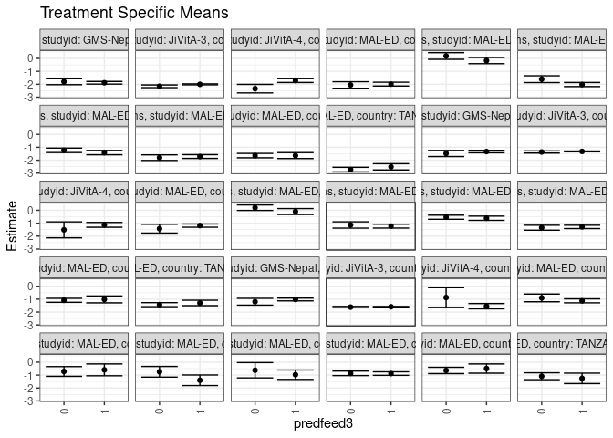

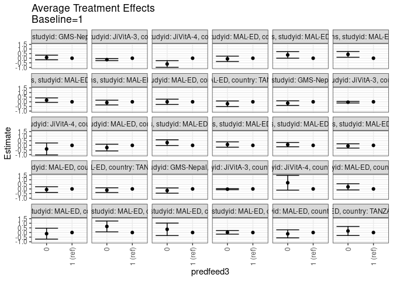

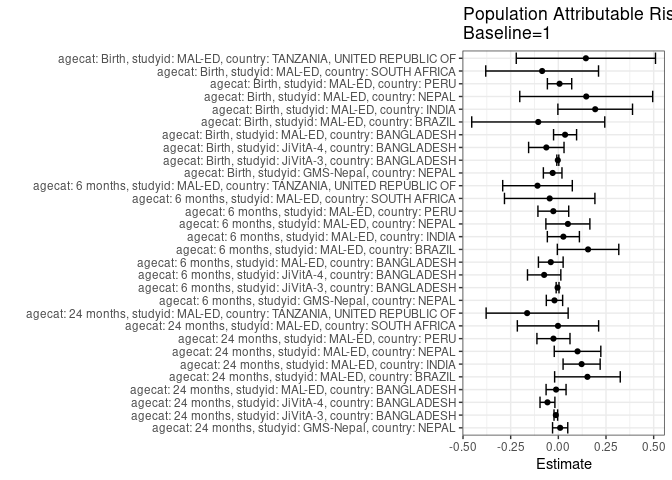

## Results Table

### Parameter: TSM

| agecat | studyid | country | intervention_level | baseline_level | estimate | ci_lower | ci_upper |
| --- | --- | --- | --- | --- | --- | --- | --- |
| Birth | GMS-Nepal | NEPAL | 1 | NA | -1.0257773 | -1.1328444 | -0.9187101 |
| Birth | GMS-Nepal | NEPAL | 0 | NA | -1.1999116 | -1.4637668 | -0.9360564 |
| Birth | JiVitA-3 | BANGLADESH | 1 | NA | -1.5900744 | -1.6137300 | -1.5664188 |
| Birth | JiVitA-3 | BANGLADESH | 0 | NA | -1.6162714 | -1.6713247 | -1.5612181 |
| Birth | JiVitA-4 | BANGLADESH | 1 | NA | -1.5443076 | -1.7494608 | -1.3391545 |
| Birth | JiVitA-4 | BANGLADESH | 0 | NA | -0.8744484 | -1.6350203 | -0.1138765 |
| Birth | MAL-ED | BANGLADESH | 1 | NA | -1.1303162 | -1.2845243 | -0.9761082 |
| Birth | MAL-ED | BANGLADESH | 0 | NA | -0.9036738 | -1.2022466 | -0.6051009 |
| Birth | MAL-ED | BRAZIL | 1 | NA | -0.5942628 | -1.0520037 | -0.1365219 |
| Birth | MAL-ED | BRAZIL | 0 | NA | -0.7193814 | -1.0969001 | -0.3418628 |
| Birth | MAL-ED | INDIA | 1 | NA | -1.4009381 | -1.8097774 | -0.9920989 |
| Birth | MAL-ED | INDIA | 0 | NA | -0.7422885 | -1.1552814 | -0.3292955 |
| Birth | MAL-ED | NEPAL | 1 | NA | -0.9697625 | -1.3347893 | -0.6047357 |
| Birth | MAL-ED | NEPAL | 0 | NA | -0.6240713 | -1.2166317 | -0.0315109 |
| Birth | MAL-ED | PERU | 1 | NA | -0.8817396 | -1.0179606 | -0.7455186 |
| Birth | MAL-ED | PERU | 0 | NA | -0.8630086 | -1.0385647 | -0.6874526 |
| Birth | MAL-ED | SOUTH AFRICA | 1 | NA | -0.4946913 | -0.8521234 | -0.1372593 |
| Birth | MAL-ED | SOUTH AFRICA | 0 | NA | -0.6382962 | -0.8845016 | -0.3920908 |
| Birth | MAL-ED | TANZANIA, UNITED REPUBLIC OF | 1 | NA | -1.2531197 | -1.6573619 | -0.8488776 |
| Birth | MAL-ED | TANZANIA, UNITED REPUBLIC OF | 0 | NA | -1.0884279 | -1.3548513 | -0.8220045 |
| 6 months | GMS-Nepal | NEPAL | 1 | NA | -1.3297327 | -1.4245892 | -1.2348762 |
| 6 months | GMS-Nepal | NEPAL | 0 | NA | -1.4793944 | -1.7155313 | -1.2432576 |
| 6 months | JiVitA-3 | BANGLADESH | 1 | NA | -1.3200089 | -1.3492204 | -1.2907973 |
| 6 months | JiVitA-3 | BANGLADESH | 0 | NA | -1.3626367 | -1.4468668 | -1.2784067 |
| 6 months | JiVitA-4 | BANGLADESH | 1 | NA | -1.1250940 | -1.3126967 | -0.9374912 |
| 6 months | JiVitA-4 | BANGLADESH | 0 | NA | -1.5143698 | -2.1311437 | -0.8975959 |
| 6 months | MAL-ED | BANGLADESH | 1 | NA | -1.1846570 | -1.3105108 | -1.0588031 |
| 6 months | MAL-ED | BANGLADESH | 0 | NA | -1.4246761 | -1.7639218 | -1.0854305 |
| 6 months | MAL-ED | BRAZIL | 1 | NA | -0.0949979 | -0.3248905 | 0.1348947 |
| 6 months | MAL-ED | BRAZIL | 0 | NA | 0.1996477 | -0.0133321 | 0.4126274 |
| 6 months | MAL-ED | INDIA | 1 | NA | -1.2266837 | -1.3754799 | -1.0778874 |
| 6 months | MAL-ED | INDIA | 0 | NA | -1.1374211 | -1.3813258 | -0.8935163 |
| 6 months | MAL-ED | NEPAL | 1 | NA | -0.6134832 | -0.7783169 | -0.4486495 |
| 6 months | MAL-ED | NEPAL | 0 | NA | -0.5348815 | -0.6931690 | -0.3765941 |
| 6 months | MAL-ED | PERU | 1 | NA | -1.2845684 | -1.4142251 | -1.1549117 |
| 6 months | MAL-ED | PERU | 0 | NA | -1.3480241 | -1.5403056 | -1.1557426 |
| 6 months | MAL-ED | SOUTH AFRICA | 1 | NA | -1.0208722 | -1.2871194 | -0.7546250 |
| 6 months | MAL-ED | SOUTH AFRICA | 0 | NA | -1.0908102 | -1.2458129 | -0.9358076 |
| 6 months | MAL-ED | TANZANIA, UNITED REPUBLIC OF | 1 | NA | -1.2937689 | -1.5034684 | -1.0840694 |
| 6 months | MAL-ED | TANZANIA, UNITED REPUBLIC OF | 0 | NA | -1.4254261 | -1.5804950 | -1.2703573 |
| 24 months | GMS-Nepal | NEPAL | 1 | NA | -1.8848598 | -1.9864454 | -1.7832741 |
| 24 months | GMS-Nepal | NEPAL | 0 | NA | -1.8028345 | -2.0321290 | -1.5735400 |
| 24 months | JiVitA-3 | BANGLADESH | 1 | NA | -2.0055709 | -2.0433708 | -1.9677711 |
| 24 months | JiVitA-3 | BANGLADESH | 0 | NA | -2.1565239 | -2.2616505 | -2.0513972 |
| 24 months | JiVitA-4 | BANGLADESH | 1 | NA | -1.7155830 | -1.8636226 | -1.5675435 |
| 24 months | JiVitA-4 | BANGLADESH | 0 | NA | -2.3390977 | -2.6687438 | -2.0094516 |
| 24 months | MAL-ED | BANGLADESH | 1 | NA | -1.9897895 | -2.1369561 | -1.8426229 |
| 24 months | MAL-ED | BANGLADESH | 0 | NA | -2.0571029 | -2.3084161 | -1.8057897 |
| 24 months | MAL-ED | BRAZIL | 1 | NA | -0.1689597 | -0.4074458 | 0.0695263 |
| 24 months | MAL-ED | BRAZIL | 0 | NA | 0.1879266 | -0.0703123 | 0.4461655 |
| 24 months | MAL-ED | INDIA | 1 | NA | -2.0215223 | -2.1789082 | -1.8641363 |
| 24 months | MAL-ED | INDIA | 0 | NA | -1.6071032 | -1.8712088 | -1.3429977 |
| 24 months | MAL-ED | NEPAL | 1 | NA | -1.4116402 | -1.5783359 | -1.2449445 |
| 24 months | MAL-ED | NEPAL | 0 | NA | -1.2354616 | -1.4084087 | -1.0625144 |
| 24 months | MAL-ED | PERU | 1 | NA | -1.7157067 | -1.8614444 | -1.5699690 |
| 24 months | MAL-ED | PERU | 0 | NA | -1.8011300 | -2.0176104 | -1.5846495 |
| 24 months | MAL-ED | SOUTH AFRICA | 1 | NA | -1.6406001 | -1.8705881 | -1.4106121 |
| 24 months | MAL-ED | SOUTH AFRICA | 0 | NA | -1.6430126 | -1.8142907 | -1.4717345 |
| 24 months | MAL-ED | TANZANIA, UNITED REPUBLIC OF | 1 | NA | -2.5131774 | -2.7554160 | -2.2709388 |
| 24 months | MAL-ED | TANZANIA, UNITED REPUBLIC OF | 0 | NA | -2.7266745 | -2.9053327 | -2.5480163 |

### Parameter: E(Y)

| agecat | studyid | country | intervention_level | baseline_level | estimate | ci_lower | ci_upper |
| --- | --- | --- | --- | --- | --- | --- | --- |
| Birth | GMS-Nepal | NEPAL | NA | NA | -1.0555240 | -1.1550843 | -0.9559638 |
| Birth | JiVitA-3 | BANGLADESH | NA | NA | -1.5928457 | -1.6158667 | -1.5698248 |
| Birth | JiVitA-4 | BANGLADESH | NA | NA | -1.6073276 | -1.8105798 | -1.4040753 |
| Birth | MAL-ED | BANGLADESH | NA | NA | -1.0949767 | -1.2319917 | -0.9579618 |
| Birth | MAL-ED | BRAZIL | NA | NA | -0.6996491 | -0.9856018 | -0.4136965 |
| Birth | MAL-ED | INDIA | NA | NA | -1.2075610 | -1.5261540 | -0.8889679 |
| Birth | MAL-ED | NEPAL | NA | NA | -0.8234615 | -1.1896049 | -0.4573182 |
| Birth | MAL-ED | PERU | NA | NA | -0.8753812 | -0.9932108 | -0.7575515 |
| Birth | MAL-ED | SOUTH AFRICA | NA | NA | -0.5797000 | -0.7788298 | -0.3805702 |
| Birth | MAL-ED | TANZANIA, UNITED REPUBLIC OF | NA | NA | -1.1086275 | -1.3310338 | -0.8862211 |
| 6 months | GMS-Nepal | NEPAL | NA | NA | -1.3499849 | -1.4387386 | -1.2612312 |
| 6 months | JiVitA-3 | BANGLADESH | NA | NA | -1.3240051 | -1.3526414 | -1.2953689 |
| 6 months | JiVitA-4 | BANGLADESH | NA | NA | -1.1994318 | -1.3808291 | -1.0180345 |
| 6 months | MAL-ED | BANGLADESH | NA | NA | -1.2242918 | -1.3439424 | -1.1046413 |
| 6 months | MAL-ED | BRAZIL | NA | NA | 0.0609091 | -0.0944768 | 0.2162950 |
| 6 months | MAL-ED | INDIA | NA | NA | -1.2002381 | -1.3274929 | -1.0729833 |
| 6 months | MAL-ED | NEPAL | NA | NA | -0.5634068 | -0.6769687 | -0.4498449 |
| 6 months | MAL-ED | PERU | NA | NA | -1.3108735 | -1.4182407 | -1.2035062 |
| 6 months | MAL-ED | SOUTH AFRICA | NA | NA | -1.0662227 | -1.1965862 | -0.9358591 |
| 6 months | MAL-ED | TANZANIA, UNITED REPUBLIC OF | NA | NA | -1.4030503 | -1.5292443 | -1.2768563 |
| 24 months | GMS-Nepal | NEPAL | NA | NA | -1.8752995 | -1.9688053 | -1.7817937 |
| 24 months | JiVitA-3 | BANGLADESH | NA | NA | -2.0187325 | -2.0554682 | -1.9819968 |
| 24 months | JiVitA-4 | BANGLADESH | NA | NA | -1.7726490 | -1.9111913 | -1.6341067 |
| 24 months | MAL-ED | BANGLADESH | NA | NA | -2.0016585 | -2.1303297 | -1.8729874 |
| 24 months | MAL-ED | BRAZIL | NA | NA | -0.0162939 | -0.1929098 | 0.1603221 |
| 24 months | MAL-ED | INDIA | NA | NA | -1.8994059 | -2.0346781 | -1.7641337 |
| 24 months | MAL-ED | NEPAL | NA | NA | -1.3109318 | -1.4313748 | -1.1904888 |
| 24 months | MAL-ED | PERU | NA | NA | -1.7412963 | -1.8630698 | -1.6195228 |
| 24 months | MAL-ED | SOUTH AFRICA | NA | NA | -1.6424525 | -1.7808926 | -1.5040124 |
| 24 months | MAL-ED | TANZANIA, UNITED REPUBLIC OF | NA | NA | -2.6768207 | -2.8213178 | -2.5323235 |

### Parameter: ATE

| agecat | studyid | country | intervention_level | baseline_level | estimate | ci_lower | ci_upper |
| --- | --- | --- | --- | --- | --- | --- | --- |
| Birth | GMS-Nepal | NEPAL | 1 | 1 | 0.0000000 | 0.0000000 | 0.0000000 |
| Birth | GMS-Nepal | NEPAL | 0 | 1 | -0.1741343 | -0.4590280 | 0.1107594 |
| Birth | JiVitA-3 | BANGLADESH | 1 | 1 | 0.0000000 | 0.0000000 | 0.0000000 |
| Birth | JiVitA-3 | BANGLADESH | 0 | 1 | -0.0261970 | -0.0817104 | 0.0293164 |
| Birth | JiVitA-4 | BANGLADESH | 1 | 1 | 0.0000000 | 0.0000000 | 0.0000000 |
| Birth | JiVitA-4 | BANGLADESH | 0 | 1 | 0.6698593 | -0.1280512 | 1.4677697 |
| Birth | MAL-ED | BANGLADESH | 1 | 1 | 0.0000000 | 0.0000000 | 0.0000000 |
| Birth | MAL-ED | BANGLADESH | 0 | 1 | 0.2266424 | -0.1097695 | 0.5630544 |
| Birth | MAL-ED | BRAZIL | 1 | 1 | 0.0000000 | 0.0000000 | 0.0000000 |
| Birth | MAL-ED | BRAZIL | 0 | 1 | -0.1251186 | -0.7157640 | 0.4655268 |
| Birth | MAL-ED | INDIA | 1 | 1 | 0.0000000 | 0.0000000 | 0.0000000 |
| Birth | MAL-ED | INDIA | 0 | 1 | 0.6586497 | 0.0729194 | 1.2443800 |
| Birth | MAL-ED | NEPAL | 1 | 1 | 0.0000000 | 0.0000000 | 0.0000000 |
| Birth | MAL-ED | NEPAL | 0 | 1 | 0.3456912 | -0.3295139 | 1.0208962 |
| Birth | MAL-ED | PERU | 1 | 1 | 0.0000000 | 0.0000000 | 0.0000000 |
| Birth | MAL-ED | PERU | 0 | 1 | 0.0187310 | -0.1779603 | 0.2154223 |
| Birth | MAL-ED | SOUTH AFRICA | 1 | 1 | 0.0000000 | 0.0000000 | 0.0000000 |
| Birth | MAL-ED | SOUTH AFRICA | 0 | 1 | -0.1436048 | -0.5802829 | 0.2930732 |
| Birth | MAL-ED | TANZANIA, UNITED REPUBLIC OF | 1 | 1 | 0.0000000 | 0.0000000 | 0.0000000 |
| Birth | MAL-ED | TANZANIA, UNITED REPUBLIC OF | 0 | 1 | 0.1646918 | -0.3249860 | 0.6543696 |
| 6 months | GMS-Nepal | NEPAL | 1 | 1 | 0.0000000 | 0.0000000 | 0.0000000 |
| 6 months | GMS-Nepal | NEPAL | 0 | 1 | -0.1496617 | -0.4028469 | 0.1035235 |
| 6 months | JiVitA-3 | BANGLADESH | 1 | 1 | 0.0000000 | 0.0000000 | 0.0000000 |
| 6 months | JiVitA-3 | BANGLADESH | 0 | 1 | -0.0426279 | -0.1278427 | 0.0425870 |
| 6 months | JiVitA-4 | BANGLADESH | 1 | 1 | 0.0000000 | 0.0000000 | 0.0000000 |
| 6 months | JiVitA-4 | BANGLADESH | 0 | 1 | -0.3892758 | -1.0338526 | 0.2553009 |
| 6 months | MAL-ED | BANGLADESH | 1 | 1 | 0.0000000 | 0.0000000 | 0.0000000 |
| 6 months | MAL-ED | BANGLADESH | 0 | 1 | -0.2400192 | -0.6020096 | 0.1219712 |
| 6 months | MAL-ED | BRAZIL | 1 | 1 | 0.0000000 | 0.0000000 | 0.0000000 |
| 6 months | MAL-ED | BRAZIL | 0 | 1 | 0.2946456 | -0.0173166 | 0.6066077 |
| 6 months | MAL-ED | INDIA | 1 | 1 | 0.0000000 | 0.0000000 | 0.0000000 |
| 6 months | MAL-ED | INDIA | 0 | 1 | 0.0892626 | -0.1972936 | 0.3758188 |
| 6 months | MAL-ED | NEPAL | 1 | 1 | 0.0000000 | 0.0000000 | 0.0000000 |
| 6 months | MAL-ED | NEPAL | 0 | 1 | 0.0786017 | -0.1505623 | 0.3077656 |
| 6 months | MAL-ED | PERU | 1 | 1 | 0.0000000 | 0.0000000 | 0.0000000 |
| 6 months | MAL-ED | PERU | 0 | 1 | -0.0634557 | -0.2958381 | 0.1689267 |
| 6 months | MAL-ED | SOUTH AFRICA | 1 | 1 | 0.0000000 | 0.0000000 | 0.0000000 |
| 6 months | MAL-ED | SOUTH AFRICA | 0 | 1 | -0.0699380 | -0.3790396 | 0.2391635 |
| 6 months | MAL-ED | TANZANIA, UNITED REPUBLIC OF | 1 | 1 | 0.0000000 | 0.0000000 | 0.0000000 |
| 6 months | MAL-ED | TANZANIA, UNITED REPUBLIC OF | 0 | 1 | -0.1316572 | -0.3892783 | 0.1259638 |
| 24 months | GMS-Nepal | NEPAL | 1 | 1 | 0.0000000 | 0.0000000 | 0.0000000 |
| 24 months | GMS-Nepal | NEPAL | 0 | 1 | 0.0820252 | -0.1660400 | 0.3300905 |
| 24 months | JiVitA-3 | BANGLADESH | 1 | 1 | 0.0000000 | 0.0000000 | 0.0000000 |
| 24 months | JiVitA-3 | BANGLADESH | 0 | 1 | -0.1509529 | -0.2592970 | -0.0426089 |
| 24 months | JiVitA-4 | BANGLADESH | 1 | 1 | 0.0000000 | 0.0000000 | 0.0000000 |
| 24 months | JiVitA-4 | BANGLADESH | 0 | 1 | -0.6235147 | -0.9844659 | -0.2625635 |
| 24 months | MAL-ED | BANGLADESH | 1 | 1 | 0.0000000 | 0.0000000 | 0.0000000 |
| 24 months | MAL-ED | BANGLADESH | 0 | 1 | -0.0673134 | -0.3590676 | 0.2244407 |
| 24 months | MAL-ED | BRAZIL | 1 | 1 | 0.0000000 | 0.0000000 | 0.0000000 |
| 24 months | MAL-ED | BRAZIL | 0 | 1 | 0.3568863 | 0.0036394 | 0.7101332 |
| 24 months | MAL-ED | INDIA | 1 | 1 | 0.0000000 | 0.0000000 | 0.0000000 |
| 24 months | MAL-ED | INDIA | 0 | 1 | 0.4144191 | 0.1064226 | 0.7224156 |
| 24 months | MAL-ED | NEPAL | 1 | 1 | 0.0000000 | 0.0000000 | 0.0000000 |
| 24 months | MAL-ED | NEPAL | 0 | 1 | 0.1761786 | -0.0634178 | 0.4157751 |
| 24 months | MAL-ED | PERU | 1 | 1 | 0.0000000 | 0.0000000 | 0.0000000 |
| 24 months | MAL-ED | PERU | 0 | 1 | -0.0854233 | -0.3431161 | 0.1722696 |
| 24 months | MAL-ED | SOUTH AFRICA | 1 | 1 | 0.0000000 | 0.0000000 | 0.0000000 |
| 24 months | MAL-ED | SOUTH AFRICA | 0 | 1 | -0.0024125 | -0.2894162 | 0.2845912 |
| 24 months | MAL-ED | TANZANIA, UNITED REPUBLIC OF | 1 | 1 | 0.0000000 | 0.0000000 | 0.0000000 |
| 24 months | MAL-ED | TANZANIA, UNITED REPUBLIC OF | 0 | 1 | -0.2134971 | -0.5163809 | 0.0893866 |

### Parameter: PAR

| agecat | studyid | country | intervention_level | baseline_level | estimate | ci_lower | ci_upper |
| --- | --- | --- | --- | --- | --- | --- | --- |
| Birth | GMS-Nepal | NEPAL | 1 | NA | -0.0297468 | -0.0785347 | 0.0190411 |
| Birth | JiVitA-3 | BANGLADESH | 1 | NA | -0.0027713 | -0.0080205 | 0.0024779 |
| Birth | JiVitA-4 | BANGLADESH | 1 | NA | -0.0630199 | -0.1558975 | 0.0298577 |
| Birth | MAL-ED | BANGLADESH | 1 | NA | 0.0353395 | -0.0250487 | 0.0957277 |
| Birth | MAL-ED | BRAZIL | 1 | NA | -0.1053863 | -0.4542797 | 0.2435071 |
| Birth | MAL-ED | INDIA | 1 | NA | 0.1933772 | -0.0023870 | 0.3891414 |
| Birth | MAL-ED | NEPAL | 1 | NA | 0.1463009 | -0.2023097 | 0.4949116 |
| Birth | MAL-ED | PERU | 1 | NA | 0.0063584 | -0.0574391 | 0.0701560 |
| Birth | MAL-ED | SOUTH AFRICA | 1 | NA | -0.0850087 | -0.3807964 | 0.2107791 |
| Birth | MAL-ED | TANZANIA, UNITED REPUBLIC OF | 1 | NA | 0.1444923 | -0.2206729 | 0.5096574 |
| 6 months | GMS-Nepal | NEPAL | 1 | NA | -0.0202522 | -0.0630887 | 0.0225844 |
| 6 months | JiVitA-3 | BANGLADESH | 1 | NA | -0.0039963 | -0.0114511 | 0.0034585 |
| 6 months | JiVitA-4 | BANGLADESH | 1 | NA | -0.0743378 | -0.1617704 | 0.0130947 |
| 6 months | MAL-ED | BANGLADESH | 1 | NA | -0.0396349 | -0.1044369 | 0.0251672 |
| 6 months | MAL-ED | BRAZIL | 1 | NA | 0.1559070 | -0.0052351 | 0.3170492 |
| 6 months | MAL-ED | INDIA | 1 | NA | 0.0264456 | -0.0576564 | 0.1105475 |
| 6 months | MAL-ED | NEPAL | 1 | NA | 0.0500764 | -0.0653194 | 0.1654723 |
| 6 months | MAL-ED | PERU | 1 | NA | -0.0263050 | -0.1070417 | 0.0544317 |
| 6 months | MAL-ED | SOUTH AFRICA | 1 | NA | -0.0453505 | -0.2825233 | 0.1918224 |
| 6 months | MAL-ED | TANZANIA, UNITED REPUBLIC OF | 1 | NA | -0.1092814 | -0.2918194 | 0.0732566 |
| 24 months | GMS-Nepal | NEPAL | 1 | NA | 0.0095603 | -0.0302916 | 0.0494122 |
| 24 months | JiVitA-3 | BANGLADESH | 1 | NA | -0.0131616 | -0.0226398 | -0.0036833 |
| 24 months | JiVitA-4 | BANGLADESH | 1 | NA | -0.0570660 | -0.0960938 | -0.0180382 |
| 24 months | MAL-ED | BANGLADESH | 1 | NA | -0.0118691 | -0.0642567 | 0.0405186 |
| 24 months | MAL-ED | BRAZIL | 1 | NA | 0.1526659 | -0.0194626 | 0.3247943 |
| 24 months | MAL-ED | INDIA | 1 | NA | 0.1221163 | 0.0248845 | 0.2193482 |
| 24 months | MAL-ED | NEPAL | 1 | NA | 0.1007084 | -0.0213863 | 0.2228031 |
| 24 months | MAL-ED | PERU | 1 | NA | -0.0255896 | -0.1123176 | 0.0611384 |
| 24 months | MAL-ED | SOUTH AFRICA | 1 | NA | -0.0018524 | -0.2150202 | 0.2113155 |
| 24 months | MAL-ED | TANZANIA, UNITED REPUBLIC OF | 1 | NA | -0.1636433 | -0.3787069 | 0.0514204 |